# Analyzing ford bike dataset

## by Muhammed Magdy

```python
# import all packages and set plots to be embedded inline
import numpy as np
import pandas as pd
import matplotlib.pyplot as plt
import seaborn as sb
import warnings
warnings.filterwarnings('ignore')
%matplotlib inline
```

```python
#loading the data
df=pd.read_csv('fordgobike-tripdata.csv')
df.head()
```

|  | duration_sec | start_time | end_time | start_station_id | start_station_name | start_station_latitude | start_station_longitude | end_station_id | end_station_name | end_station_latitude | end_station_longitude | bike_id | user_type | member_birth_year | member_gender | bike_share_for_all_trip |
| --- | --- | --- | --- | --- | --- | --- | --- | --- | --- | --- | --- | --- | --- | --- | --- | --- |
| 0 | 52185 | 2019-02-28 17:32:10.1450 | 2019-03-01 08:01:55.9750 | 21.0 | Montgomery St BART Station (Market St at 2nd St) | 37.789625 | -122.400811 | 13.0 | Commercial St at Montgomery St | 37.794231 | -122.402923 | 4902 | Customer | 1984.0 | Male | No |
| 1 | 42521 | 2019-02-28 18:53:21.7890 | 2019-03-01 06:42:03.0560 | 23.0 | The Embarcadero at Steuart St | 37.791464 | -122.391034 | 81.0 | Berry St at 4th St | 37.775880 | -122.393170 | 2535 | Customer | NaN | NaN | No |
| 2 | 61854 | 2019-02-28 12:13:13.2180 | 2019-03-01 05:24:08.1460 | 86.0 | Market St at Dolores St | 37.769305 | -122.426826 | 3.0 | Powell St BART Station (Market St at 4th St) | 37.786375 | -122.404904 | 5905 | Customer | 1972.0 | Male | No |
| 3 | 36490 | 2019-02-28 17:54:26.0100 | 2019-03-01 04:02:36.8420 | 375.0 | Grove St at Masonic Ave | 37.774836 | -122.446546 | 70.0 | Central Ave at Fell St | 37.773311 | -122.444293 | 6638 | Subscriber | 1989.0 | Other | No |
| 4 | 1585 | 2019-02-28 23:54:18.5490 | 2019-03-01 00:20:44.0740 | 7.0 | Frank H Ogawa Plaza | 37.804562 | -122.271738 | 222.0 | 10th Ave at E 15th St | 37.792714 | -122.248780 | 4898 | Subscriber | 1974.0 | Male | Yes |

```python
# Make a copy of data to modify it
bike=df.copy()
```

```python
# Make an age column
bike['age']=2021-bike['member_birth_year']
bike.head()
```

|  | duration_sec | start_time | end_time | start_station_id | start_station_name | start_station_latitude | start_station_longitude | end_station_id | end_station_name | end_station_latitude | end_station_longitude | bike_id | user_type | member_birth_year | member_gender | bike_share_for_all_trip | age |
| --- | --- | --- | --- | --- | --- | --- | --- | --- | --- | --- | --- | --- | --- | --- | --- | --- | --- |
| 0 | 52185 | 2019-02-28 17:32:10.1450 | 2019-03-01 08:01:55.9750 | 21.0 | Montgomery St BART Station (Market St at 2nd St) | 37.789625 | -122.400811 | 13.0 | Commercial St at Montgomery St | 37.794231 | -122.402923 | 4902 | Customer | 1984.0 | Male | No | 37.0 |
| 1 | 42521 | 2019-02-28 18:53:21.7890 | 2019-03-01 06:42:03.0560 | 23.0 | The Embarcadero at Steuart St | 37.791464 | -122.391034 | 81.0 | Berry St at 4th St | 37.775880 | -122.393170 | 2535 | Customer | NaN | NaN | No | NaN |
| 2 | 61854 | 2019-02-28 12:13:13.2180 | 2019-03-01 05:24:08.1460 | 86.0 | Market St at Dolores St | 37.769305 | -122.426826 | 3.0 | Powell St BART Station (Market St at 4th St) | 37.786375 | -122.404904 | 5905 | Customer | 1972.0 | Male | No | 49.0 |
| 3 | 36490 | 2019-02-28 17:54:26.0100 | 2019-03-01 04:02:36.8420 | 375.0 | Grove St at Masonic Ave | 37.774836 | -122.446546 | 70.0 | Central Ave at Fell St | 37.773311 | -122.444293 | 6638 | Subscriber | 1989.0 | Other | No | 32.0 |
| 4 | 1585 | 2019-02-28 23:54:18.5490 | 2019-03-01 00:20:44.0740 | 7.0 | Frank H Ogawa Plaza | 37.804562 | -122.271738 | 222.0 | 10th Ave at E 15th St | 37.792714 | -122.248780 | 4898 | Subscriber | 1974.0 | Male | Yes | 47.0 |

```python
# Know the null values in the data
bike.isna().sum()
```

```
duration_sec                  0
start_time                    0
end_time                      0
start_station_id            197
start_station_name          197
start_station_latitude        0
start_station_longitude       0
end_station_id              197
end_station_name            197
end_station_latitude          0
end_station_longitude         0
bike_id                       0
user_type                     0
member_birth_year          8265
member_gender              8265
bike_share_for_all_trip       0
age                        8265
dtype: int64
```

```python
# the null values are small so i will drop it
bike=bike.dropna()
bike.isna().sum()
```

```
duration_sec               0
start_time                 0
end_time                   0
start_station_id           0
start_station_name         0
start_station_latitude     0
start_station_longitude    0
end_station_id             0
end_station_name           0
end_station_latitude       0
end_station_longitude      0
bike_id                    0
user_type                  0
member_birth_year          0
member_gender              0
bike_share_for_all_trip    0
age                        0
dtype: int64
```

```python
# convert the data types of age, birth year, start station id and end station id to int

bike['age']=bike['age'].astype(int)
bike['member_birth_year']=bike['member_birth_year'].astype(int)
bike['end_station_id']=bike['end_station_id'].astype(int)
bike['start_station_id']=bike['start_station_id'].astype(int)


# Convert data types of start and end time to datetime to ease of use

bike['start_time']=pd.to_datetime(bike['start_time'])
bike['end_time']=pd.to_datetime(bike['end_time'])
```

```python
# Make the hour column to ease of use
bike['hour']=bike['start_time'].dt.hour

# know the day of the week and set it to names
daysnames={0:'Monday', 1:'Tuesday', 2:'Wednesday', 3:'Thursday', 4:'Friday', 5:'Saturday', 6:'Sunday'}
bike['weekday']=bike['start_time'].dt.dayofweek.map(daysnames)
bike['weekday'] = pd.Categorical(bike['weekday'] , categories=
    ['Monday','Tuesday','Wednesday','Thursday','Friday','Saturday', 'Sunday'],
    ordered=True)
```

```python
# make a column to know the duration in minutes
bike['duration_min']=bike['duration_sec']/60
```

```python
bike.info()
```

```
<class 'pandas.core.frame.DataFrame'>
Int64Index: 174952 entries, 0 to 183411
Data columns (total 20 columns):
 #   Column                   Non-Null Count   Dtype
---  ------                   --------------   -----
 0   duration_sec             174952 non-null  int64
 1   start_time               174952 non-null  datetime64[ns]
 2   end_time                 174952 non-null  datetime64[ns]
 3   start_station_id         174952 non-null  int32
 4   start_station_name       174952 non-null  object
 5   start_station_latitude   174952 non-null  float64
 6   start_station_longitude  174952 non-null  float64
 7   end_station_id           174952 non-null  int32
 8   end_station_name         174952 non-null  object
 9   end_station_latitude     174952 non-null  float64
 10  end_station_longitude    174952 non-null  float64
 11  bike_id                  174952 non-null  int64
 12  user_type                174952 non-null  object
 13  member_birth_year        174952 non-null  int32
 14  member_gender            174952 non-null  object
 15  bike_share_for_all_trip  174952 non-null  object
 16  age                      174952 non-null  int32
 17  hour                     174952 non-null  int64
 18  weekday                  174952 non-null  category
 19  duration_min             174952 non-null  float64
dtypes: category(1), datetime64[ns](2), float64(5), int32(4), int64(3), object(5)
memory usage: 24.2+ MB
```

```python
bike.describe()
```

|  | duration_sec | start_station_id | start_station_latitude | start_station_longitude | end_station_id | end_station_latitude | end_station_longitude | bike_id | member_birth_year | age | hour | duration_min |
| --- | --- | --- | --- | --- | --- | --- | --- | --- | --- | --- | --- | --- |
| count | 174952.000000 | 174952.000000 | 174952.000000 | 174952.000000 | 174952.000000 | 174952.000000 | 174952.000000 | 174952.000000 | 174952.000000 | 174952.000000 | 174952.000000 | 174952.000000 |
| mean | 704.002744 | 139.002126 | 37.771220 | -122.351760 | 136.604486 | 37.771414 | -122.351335 | 4482.587555 | 1984.803135 | 36.196865 | 13.456165 | 11.733379 |
| std | 1642.204905 | 111.648819 | 0.100391 | 0.117732 | 111.335635 | 0.100295 | 0.117294 | 1659.195937 | 10.118731 | 10.118731 | 4.734282 | 27.370082 |
| min | 61.000000 | 3.000000 | 37.317298 | -122.453704 | 3.000000 | 37.317298 | -122.453704 | 11.000000 | 1878.000000 | 20.000000 | 0.000000 | 1.016667 |
| 25% | 323.000000 | 47.000000 | 37.770407 | -122.411901 | 44.000000 | 37.770407 | -122.411647 | 3799.000000 | 1980.000000 | 29.000000 | 9.000000 | 5.383333 |
| 50% | 510.000000 | 104.000000 | 37.780760 | -122.398279 | 101.000000 | 37.781010 | -122.397437 | 4960.000000 | 1987.000000 | 34.000000 | 14.000000 | 8.500000 |
| 75% | 789.000000 | 239.000000 | 37.797320 | -122.283093 | 238.000000 | 37.797673 | -122.286533 | 5505.000000 | 1992.000000 | 41.000000 | 17.000000 | 13.150000 |
| max | 84548.000000 | 398.000000 | 37.880222 | -121.874119 | 398.000000 | 37.880222 | -121.874119 | 6645.000000 | 2001.000000 | 143.000000 | 23.000000 | 1409.133333 |

### What is/are the main feature(s) of interest in your dataset?

> The main idea is to know the peak hours and weekdays that gave us the most trip durations.

### What features in the dataset do you think will help support your investigation into your feature(s) of interest?

> Duration, age, gender, weekday and hour columns will be the most helpful column for me.

## Univariate Exploration

> In this section, investigate distributions of individual variables. If you see unusual points or outliers, take a deeper look to clean things up and prepare yourself to look at relationships between variables.

```python
# set the color variable and the theme color for ease of use
color=sb.color_palette()[0]
sb.set_theme(style="darkgrid")
```

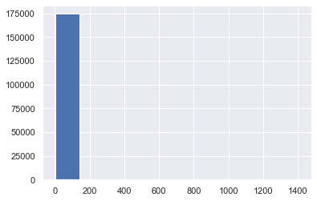

```python
plt.hist(data=bike,x='duration_min')
```

```python
bike.duration_min.describe()
```

```
count    174952.000000
mean         11.733379
std          27.370082
min           1.016667
25%           5.383333
50%           8.500000
75%          13.150000
max        1409.133333
Name: duration_min, dtype: float64
```

**The data is not distributed normally. Let's calculate of IQR:**

> IQR = Q3 - Q1 = 13.15 - 5.38=7.77

> Upper Whisker Bound = (1.5 * IQR) + Q3 =11.65 + 13.15 = 24.805

```python
np.log10(bike.duration_min.describe())
```

```
count    5.242919
mean     1.069423
std      1.437276
min      0.007179
25%      0.731051
50%      0.929419
75%      1.118926
max      3.148952
Name: duration_min, dtype: float64
```

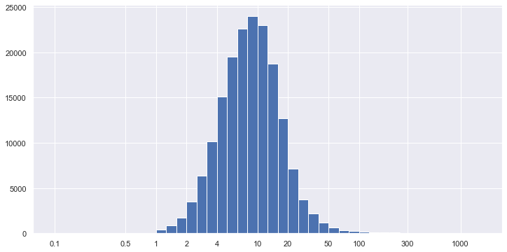

```python
# make a plot with log xticks to see the distribution for the trips time in minutes
bins = 10 ** np.arange(-1, np.log10(bike.duration_min.max())+0.1, 0.1)

ticks = [0.1, 0.5,1,2,4, 10, 20,50 ,100, 300, 1000]
labels = ['{}'.format(v) for v in ticks]

plt.figure(figsize=(12,6))
plt.hist(data=bike, x='duration_min', bins=bins)
plt.xscale('log')

plt.xticks(ticks, labels);
```

```python
bike.age.describe()
```

```
count    174952.000000
mean         36.196865
std          10.118731
min          20.000000
25%          29.000000
50%          34.000000
75%          41.000000
max         143.000000
Name: age, dtype: float64
```

**IQR = Q3 - Q1 = 41 - 29**

**Upper Whisker Bound = (1.5 * IQR) + Q3 = 18 + 41 = 59**

```python
bike=bike[bike.age<=60]
```

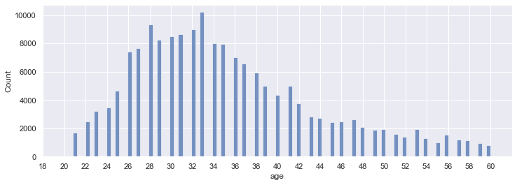

```python
# Make a plot for age to know the ditribution of ages
plt.figure(figsize=(12,4))
plt.xticks(np.arange(18,62,2),np.arange(18,62,2))
sb.histplot(data = bike, x = 'age')
```

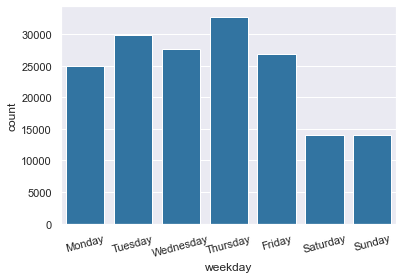

```python
# know the average daily trips in week
plt.xticks(rotation=15)
sb.countplot(data = bike, x = 'weekday',color=color)
```

> **I notice a decrease in holidays and that is logical**

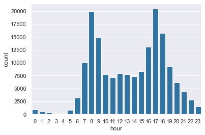

```python
# A plot for the hours of the day
sb.countplot(data = bike, x = 'hour',color=color)
```

> **There is increase in bikes used in work hours from 7 am to 7 pm**

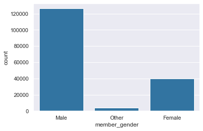

```python
# plot for the ratio in gender
sb.countplot(data = bike, x = 'member_gender',color=color)
```

> **Most users are males**

```
 [Text(0.3255180769961959, -1.0507321169302377, 'Subscriber'),
 [Text(0.17755531472519773, -0.5731266092346751, '90.4%'),
```

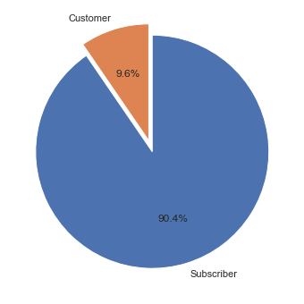

```python
# plot for the user type
plt.figure(figsize=(12,6))
plt.pie(bike.user_type.value_counts(), explode=[0, 0.1], labels=['Subscriber','Customer'], startangle=90, counterclock=False, autopct='%1.1f%%')
```

> **Customers are 9.6% of the dataset**

### Discuss the distribution(s) of your variable(s) of interest. Were there any unusual points? Did you need to perform any transformations?

> **As mentioned before I added a new column for duration in minutes for every trip to ease of investigation**

### Of the features you investigated, were there any unusual distributions? Did you perform any operations on the data to tidy, adjust, or change the form of the data? If so, why did you do this?

> **The data was tidy but i needed to add hour and weekday columns to ease of use**

## Bivariate Exploration

> In this section, investigate relationships between pairs of variables in your data. Make sure the variables that you cover here have been introduced in some fashion in the previous section (univariate exploration).

```python
bike.head()
```

|  | duration_sec | start_time | end_time | start_station_id | start_station_name | start_station_latitude | start_station_longitude | end_station_id | end_station_name | end_station_latitude | end_station_longitude | bike_id | user_type | member_birth_year | member_gender | bike_share_for_all_trip | age | hour | weekday | duration_min |
| --- | --- | --- | --- | --- | --- | --- | --- | --- | --- | --- | --- | --- | --- | --- | --- | --- | --- | --- | --- | --- |
| 0 | 52185 | 2019-02-28 17:32:10.145 | 2019-03-01 08:01:55.975 | 21 | Montgomery St BART Station (Market St at 2nd St) | 37.789625 | -122.400811 | 13 | Commercial St at Montgomery St | 37.794231 | -122.402923 | 4902 | Customer | 1984 | Male | No | 37 | 17 | Thursday | 869.750000 |
| 2 | 61854 | 2019-02-28 12:13:13.218 | 2019-03-01 05:24:08.146 | 86 | Market St at Dolores St | 37.769305 | -122.426826 | 3 | Powell St BART Station (Market St at 4th St) | 37.786375 | -122.404904 | 5905 | Customer | 1972 | Male | No | 49 | 12 | Thursday | 1030.900000 |
| 3 | 36490 | 2019-02-28 17:54:26.010 | 2019-03-01 04:02:36.842 | 375 | Grove St at Masonic Ave | 37.774836 | -122.446546 | 70 | Central Ave at Fell St | 37.773311 | -122.444293 | 6638 | Subscriber | 1989 | Other | No | 32 | 17 | Thursday | 608.166667 |
| 4 | 1585 | 2019-02-28 23:54:18.549 | 2019-03-01 00:20:44.074 | 7 | Frank H Ogawa Plaza | 37.804562 | -122.271738 | 222 | 10th Ave at E 15th St | 37.792714 | -122.248780 | 4898 | Subscriber | 1974 | Male | Yes | 47 | 23 | Thursday | 26.416667 |
| 6 | 1147 | 2019-02-28 23:55:35.104 | 2019-03-01 00:14:42.588 | 300 | Palm St at Willow St | 37.317298 | -121.884995 | 312 | San Jose Diridon Station | 37.329732 | -121.901782 | 3803 | Subscriber | 1983 | Female | No | 38 | 23 | Thursday | 19.116667 |

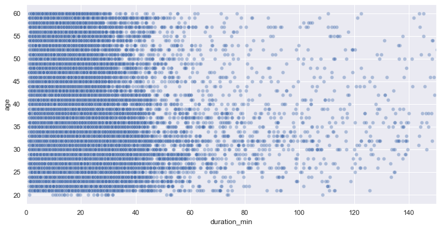

```python
# plot between the duration and age
plt.figure(figsize=(12,6))
plt.xlim(0,150)

sb.scatterplot(data=bike,y='age',x='duration_min',alpha=.4)
```

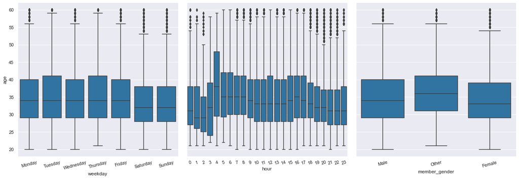

```python
def box(x,y,**kwargs):
    """ function to make box plot for the pairgrid """
    plt.xticks(rotation=15)
    sb.boxplot(x,y,color=color)

# plots between age and weekday , hour and gender
plt.figure(figsize = [15, 15]);
g = sb.PairGrid(data = bike, y_vars = ['age'], x_vars = ['weekday','hour','member_gender'], height = 6);
g.map(box);
```

> **There is a decrease in age in holidays**

> **There is an increase in ages in work hours**

> **Male bikers are older than females**

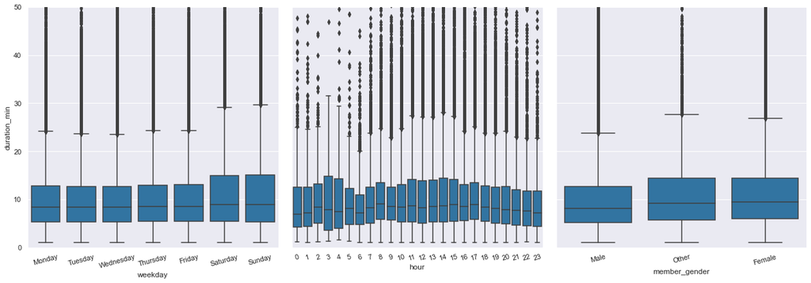

```python
def box2(x,y,**kwargs):
    """ the same function in previous cell but added a limit for the y axis"""
    plt.ylim(0,50)
    plt.xticks(rotation=15)
    sb.boxplot(x,y,color=color)

# plots between duration and weekday , hour and gender
plt.figure(figsize = [15, 15]);
g = sb.PairGrid(data = bike, y_vars = ['duration_min'], x_vars = ['weekday','hour','member_gender'], height = 6);
g.map(box2);
```

> **Trips duration increase in holidays**

> **The female bikers trips takes more time**

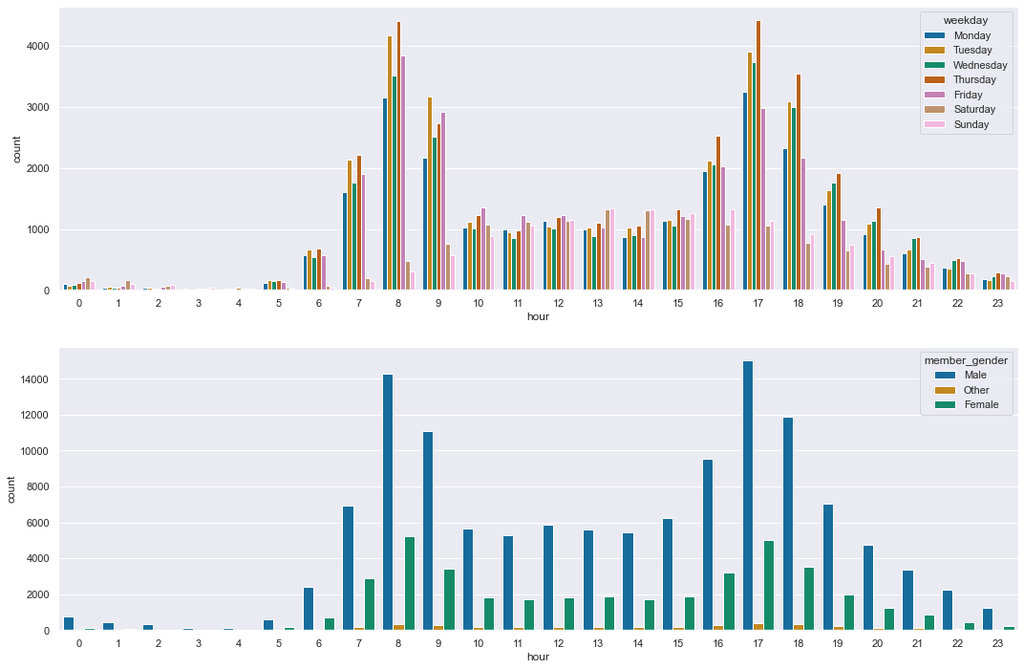

```python
plt.figure(figsize=(18,12))

# plot to know the relation between the hour and weekday
plt.subplot(2,1,1)
sb.countplot(data = bike, x = 'hour', hue = 'weekday', palette = 'colorblind');

# plot to know the relation between the hour and gender
plt.subplot(2,1,2)
sb.countplot(data = bike, x = 'hour', hue = 'member_gender', palette = 'colorblind');
```

### Talk about some of the relationships you observed in this part of the investigation. How did the feature(s) of interest vary with other features in the dataset?

> Trips duration increase in holidays

> The female bikers trips takes more time

## Multivariate Exploration

> Create plots of three or more variables to investigate your data even further. Make sure that your investigations are justified, and follow from your work in the previous sections.

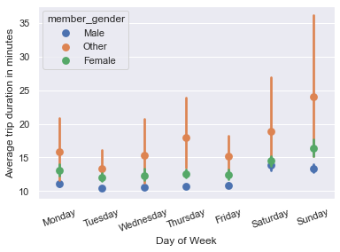

```python
# plot between minutes, weekdays and gender
sb.pointplot(data=bike, x='weekday', y='duration_min', hue='member_gender',  linestyles="")
plt.xlabel('Day of Week')
plt.xticks(rotation=20)
plt.ylabel('Average trip duration in minutes')
```

**As mentioned before the female bikers usually takes more time on a trip**

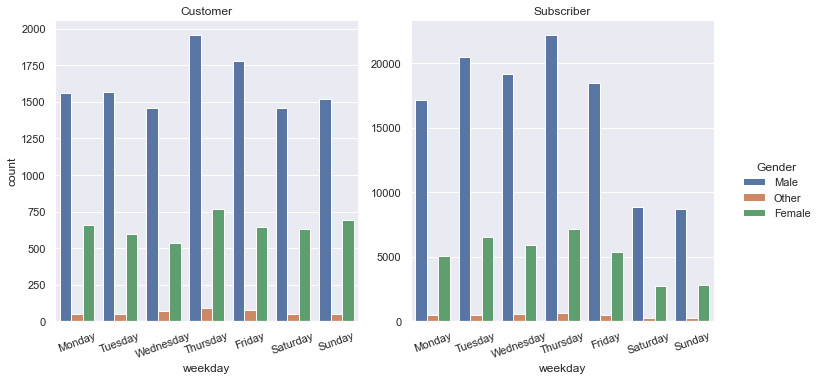

```python
#plot between user tybe, gender and weekdays
g = sb.catplot(data=bike, x='weekday', col="user_type", hue="member_gender", kind='count', sharey = False)
g.set_titles("{col_name}")
g._legend.set_title('Gender')
g.set_xticklabels(rotation=20)
```

**The ratio between female customers and male customers is bigger than the ratio between the female subscribers and male subscribers**

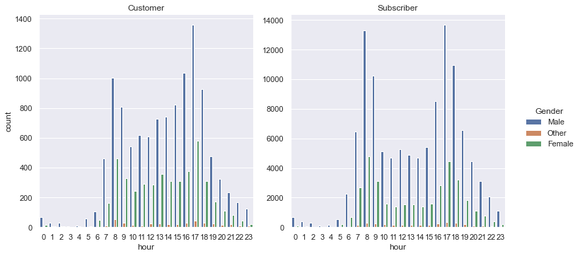

```python
#plot between user tybe, gender and hours
plt.figure(figsize=(12,6))
g = sb.catplot(data=bike, x='hour', col="user_type", hue='member_gender', kind='count', sharey = False)
g._legend.set_title('Gender')
g.set_titles("{col_name}")
```

**The ratio of male users is so big comparing to female users at any time**

### Talk about some of the relationships you observed in this part of the investigation. Were there features that strengthened each other in terms of looking at your feature(s) of interest?

> As seen before there are peak hours in the day that we have most trips and times that have no trips

> The trip duration is longer for females

> The gender ratio is approximately the same 24/7

### Were there any interesting or surprising interactions between features?

> It was intersting that the customer number are tenth of the subcribers

> I see that the (other) gender takes very big time comparing to other genders

```python
# save the cleaned data
bike.to_csv('cleanfordbikes.csv',index=False)
```